# 1. Segmenting and Clustering Neighborhoods in Toronto

# The main idea of this project is cluster neighborhoods in Toronto.

## We will start from collecting and preparing data

```python
#import libraries
import pandas as pd
import numpy as np
import requests
from bs4 import BeautifulSoup
pd.set_option('display.max_rows', 100)
pd.set_option('display.max_columns', 500)
pd.set_option('display.width', 1000)
```

#### Obtane data from Wikipedia page using Beautiful Soap

```python
#url from where we going to scribe table with zip-codes
codes_url = 'https://en.wikipedia.org/wiki/List_of_postal_codes_of_Canada:_M'
```

```python
#get content of web-page
page = requests.get(codes_url)
print(page.status_code)
```

```
200
```

```python
#parse page
soup = BeautifulSoup(page.content, 'html')
```

#### Find table and put it into a DataFrame

```python
canada_postcodes = soup.find('table',{'class':'wikitable sortable'})
df_postcodes = pd.concat(pd.read_html(canada_postcodes.decode()))
```

```python
df_postcodes.head()
```

|  | Postal Code | Borough | Neighborhood |
| --- | --- | --- | --- |
| 0 | M1A | Not assigned | Not assigned |
| 1 | M2A | Not assigned | Not assigned |
| 2 | M3A | North York | Parkwoods |
| 3 | M4A | North York | Victoria Village |
| 4 | M5A | Downtown Toronto | Regent Park, Harbourfront |

```python
#Let's see if numbers of 'Not assigned' the same in Borough as in Neighborhood
df_postcodes['Borough'].value_counts()[0] == df_postcodes['Neighborhood'].value_counts()[0]
```

```
True
```

#### After we make sure there is no full Borough with empty Neighborhood we can drope all rows with 'Not assigned'

```python
df_postcodes.replace("Not assigned", np.nan, inplace = True)
df_postcodes
```

|  | Postal Code | Borough | Neighborhood |
| --- | --- | --- | --- |
| 0 | M1A | NaN | NaN |
| 1 | M2A | NaN | NaN |
| 2 | M3A | North York | Parkwoods |
| 3 | M4A | North York | Victoria Village |
| 4 | M5A | Downtown Toronto | Regent Park, Harbourfront |
| ... | ... | ... | ... |
| 175 | M5Z | NaN | NaN |
| 176 | M6Z | NaN | NaN |
| 177 | M7Z | NaN | NaN |
| 178 | M8Z | Etobicoke | Mimico NW, The Queensway West, South of Bloor,... |
| 179 | M9Z | NaN | NaN |

180 rows × 3 columns

#### Drop Postal codes with Borough 'Not assigned'

```python
df_postcodes.dropna(subset = ['Borough'], inplace = True)
```

```python
#Reset index
df_postcodes.reset_index(drop=True, inplace=True)
df_postcodes.head(12)
```

|  | Postal Code | Borough | Neighborhood |
| --- | --- | --- | --- |
| 0 | M3A | North York | Parkwoods |
| 1 | M4A | North York | Victoria Village |
| 2 | M5A | Downtown Toronto | Regent Park, Harbourfront |
| 3 | M6A | North York | Lawrence Manor, Lawrence Heights |
| 4 | M7A | Downtown Toronto | Queen's Park, Ontario Provincial Government |
| 5 | M9A | Etobicoke | Islington Avenue, Humber Valley Village |
| 6 | M1B | Scarborough | Malvern, Rouge |
| 7 | M3B | North York | Don Mills |
| 8 | M4B | East York | Parkview Hill, Woodbine Gardens |
| 9 | M5B | Downtown Toronto | Garden District, Ryerson |
| 10 | M6B | North York | Glencairn |
| 11 | M9B | Etobicoke | West Deane Park, Princess Gardens, Martin Grov... |

```python
#shape of a dataframe
df_postcodes.shape
```

```
(103, 3)
```

# 2. Get the latitude and the longitude coordinates of each neighborhood

```python
#read csv file with coordinates
coordinates = pd.read_csv('Geospatial_Coordinates.csv')
```

```python
coordinates.head()
```

|  | Postal Code | Latitude | Longitude |
| --- | --- | --- | --- |
| 0 | M1B | 43.806686 | -79.194353 |
| 1 | M1C | 43.784535 | -79.160497 |
| 2 | M1E | 43.763573 | -79.188711 |
| 3 | M1G | 43.770992 | -79.216917 |
| 4 | M1H | 43.773136 | -79.239476 |

#### Add coordinates to postcodes using methos merged

```python
df = pd.merge_ordered(df_postcodes, coordinates, left_by = 'Postal Code', fill_method = 'ffil', how = 'left')
```

```python
df.head()
```

|  | Postal Code | Borough | Neighborhood | Latitude | Longitude |
| --- | --- | --- | --- | --- | --- |
| 0 | M3A | North York | Parkwoods | 43.753259 | -79.329656 |
| 1 | M4A | North York | Victoria Village | 43.725882 | -79.315572 |
| 2 | M5A | Downtown Toronto | Regent Park, Harbourfront | 43.654260 | -79.360636 |
| 3 | M6A | North York | Lawrence Manor, Lawrence Heights | 43.718518 | -79.464763 |
| 4 | M7A | Downtown Toronto | Queen's Park, Ontario Provincial Government | 43.662301 | -79.389494 |

```python
df.shape
```

```
(103, 5)
```

# 3. Exploring and clustering the neighborhoods in Toronto

## 3.1 Exploring all neighborhoods in Toronto

```python
from sklearn.cluster import KMeans
import folium
from sklearn.cluster import DBSCAN
import geocoder
import json
from pandas.io.json import json_normalize
import configparser
import matplotlib.cm as cm
import matplotlib.colors as colors
import matplotlib.pyplot as plt
```

```python
g = geocoder.osm('Toronto, Ontario')
g.latlng
```

```
[43.6534817, -79.3839347]
```

```python
g = geocoder.osm('Toronto, Ontario')
latitude = g.latlng[0]
longitude = g.latlng[1]
print(f'The geograpical coordinate of Toronto are {g.latlng[0]},{g.latlng[1]}.')
```

```
The geograpical coordinate of Toronto are 43.6534817,-79.3839347.
```

#### Create a map with all boroughs

```python
map_toronto = folium.Map(location = [latitude, longitude], zoom_start = 10)

#add markers
for lat, lng, borough, neighborhood in zip(df['Latitude'], df['Longitude'], df['Borough'], df['Neighborhood']):
    label = f'{neighborhood}, {borough}'
    label = folium.Popup(label, parse_html = 'True')
    folium.CircleMarker(
        [lat, lng],
        radius = 3,
        popup = label,
        color = 'Blue',
        fill = True,
        fill_color = '#3186cc',
        fill_opacity = 0.7,
        parse_html = False).add_to(map_toronto)

map_toronto
```

Make this Notebook Trusted to load map: File -> Trust Notebook

[interactive chart not shown]

### Get Foursquare Credentials and Version

```python
config = configparser.ConfigParser()
config.read('example.ini')
config.sections()
```

```
['Foursquare']
```

```python
CLIENT_ID = config['Foursquare']['CLIENT_ID']
CLIENT_SECRET = config['Foursquare']['CLIENT_SECRET']
VERSION = config['Foursquare']['VERSION']
```

# 3.2 Choosing bouroughs and creating DataFrame

#### I want to choose between North York borough and bouroughs contains word Toronto

```python
NorthYork_borough = df[df['Borough'] == 'North York'].reset_index(drop=True)
NorthYork_borough.shape
```

```
(24, 5)
```

```python
toronto_ngh = df[df['Borough'].str.contains('Toronto')].reset_index(drop=True)
toronto_ngh.shape
```

```
(39, 5)
```

### let's choose boroughs contains Toronto in it, becouse it has more venues

```python
toronto_ngh.head()
```

|  | Postal Code | Borough | Neighborhood | Latitude | Longitude |
| --- | --- | --- | --- | --- | --- |
| 0 | M5A | Downtown Toronto | Regent Park, Harbourfront | 43.654260 | -79.360636 |
| 1 | M7A | Downtown Toronto | Queen's Park, Ontario Provincial Government | 43.662301 | -79.389494 |
| 2 | M5B | Downtown Toronto | Garden District, Ryerson | 43.657162 | -79.378937 |
| 3 | M5C | Downtown Toronto | St. James Town | 43.651494 | -79.375418 |
| 4 | M4E | East Toronto | The Beaches | 43.676357 | -79.293031 |

## Visualise borough

##### As we don't know which centre to use for a map, I sugest to use mean value for all latitudes and lontitudes of toronto_ngh

```python
latitude = toronto_ngh['Latitude'].mean()
longitude = toronto_ngh['Longitude'].mean()
```

```python
print(f'The geograpical coordinate are {latitude}, {longitude}.')
```

```
The geograpical coordinate are 43.66713498717949, -79.38987324871795.
```

```python
map_toronto_borough = folium.Map(location=[latitude+0.005,longitude], zoom_start=12)
#I added 0.005 to centralize map

#create markers
for lat, lng, label in zip(toronto_ngh['Latitude'], toronto_ngh['Longitude'], toronto_ngh['Neighborhood']):
    label = folium.Popup(label, parse_html = True)
    folium.CircleMarker(
        [lat, lng],
        radius = 5,
        popup = label,
        color='blue',
        fill=True,
        fill_color='#3186cc',
        fill_opacity=0.7,
        parse_html=False
    ).add_to(map_toronto_borough)

map_toronto_borough
```

Make this Notebook Trusted to load map: File -> Trust Notebook

[interactive chart not shown]

# 3.3 Explore first neighborhood

```python
toronto_ngh.loc[0, 'Neighborhood']
```

```
'Regent Park, Harbourfront'
```

```python
neighborhood_latitude = toronto_ngh.loc[0, 'Latitude']
neighborhood_longitude = toronto_ngh.loc[0, 'Longitude']
neighborhood_name = toronto_ngh.loc[0, 'Neighborhood']
```

```python
# Create quary within 500 meters with limit 100 venues
LIMIT = 100
radius = 500
url = f'https://api.foursquare.com/v2/venues/explore?&client_id={CLIENT_ID}&client_secret={CLIENT_SECRET}&v={VERSION}&ll={neighborhood_latitude},{neighborhood_longitude}&radius={radius}&limit={LIMIT}'
```

```python
results = requests.get(url).json()
#results
```

### Create function that extracts the category of the venue

```python
def get_category_type(row):
    try:
        categories_list = row['categories']
    except:
        categories_list = row['venue.categories']
    if len(categories_list) == 0:
        return None
    else:
        return categories_list[0]['name']
```

```python
venues = results['response']['groups'][0]['items']

nearby_venues = json_normalize(venues)

# filter columns
filtered_columns = ['venue.name', 'venue.categories', 'venue.location.lat', 'venue.location.lng']
nearby_venues =nearby_venues.loc[:, filtered_columns]

# filter the category for each row
nearby_venues['venue.categories'] = nearby_venues.apply(get_category_type, axis=1)

# clean columns
nearby_venues.columns = [col.split(".")[-1] for col in nearby_venues.columns]

nearby_venues.head()
```

|  | name | categories | lat | lng |
| --- | --- | --- | --- | --- |
| 0 | Roselle Desserts | Bakery | 43.653447 | -79.362017 |
| 1 | Tandem Coffee | Coffee Shop | 43.653559 | -79.361809 |
| 2 | Cooper Koo Family YMCA | Distribution Center | 43.653249 | -79.358008 |
| 3 | Body Blitz Spa East | Spa | 43.654735 | -79.359874 |
| 4 | Dominion Pub and Kitchen | Pub | 43.656919 | -79.358967 |

```python
print(f'{nearby_venues.shape[0]} venues were returned by Foursquare.')
```

```
46 venues were returned by Foursquare.
```

#### In radius of 500 meters 46 venues. It's really busy neighborhood.

# 3.4 Explore all neighborhoods in chosen Borough

### Function for creating Data Frame with all venues with radius 500 meters for all neighborhoods

```python
def getNearbyVenues(names, latitudes, longitudes, radius=500):

    venues_list=[]
    s = requests.Session()
    for name, lat, lng in zip(names, latitudes, longitudes):
        print(name)

        # create the API request URL
        payload = {'client_id': CLIENT_ID,
           'client_secret': CLIENT_SECRET,
           'v': VERSION,
           'll': f'{lat},{lng}',
           'radius': radius,
           'limit' : LIMIT}


        # make the GET request

        #to prevent code to crush
        r = None
        while r is None or r.status_code != 200:
            r = s.get('https://api.foursquare.com/v2/venues/explore', params=payload)


        results = r.json()["response"]['groups'][0]['items']

        # return only relevant information for each nearby venue
        venues_list.append([(
            name,
            lat,
            lng,
            v['venue']['name'],
            v['venue']['location']['lat'],
            v['venue']['location']['lng'],
            v['venue']['categories'][0]['name']) for v in results])

    nearby_venues = pd.DataFrame([item for venue_list in venues_list for item in venue_list])
    nearby_venues.columns = ['Neighborhood',
                  'Neighborhood Latitude',
                  'Neighborhood Longitude',
                  'Venue',
                  'Venue Latitude',
                  'Venue Longitude',
                  'Venue Category']

    return(nearby_venues)
```

```python
toronto_venues = getNearbyVenues(names=toronto_ngh['Neighborhood'],
                                   latitudes=toronto_ngh['Latitude'],
                                   longitudes=toronto_ngh['Longitude']
                                  )
```

```
Regent Park, Harbourfront
Queen's Park, Ontario Provincial Government
Garden District, Ryerson
St. James Town
The Beaches
Berczy Park
Central Bay Street
Christie
Richmond, Adelaide, King
Dufferin, Dovercourt Village
Harbourfront East, Union Station, Toronto Islands
Little Portugal, Trinity
The Danforth West, Riverdale
Toronto Dominion Centre, Design Exchange
Brockton, Parkdale Village, Exhibition Place
India Bazaar, The Beaches West
Commerce Court, Victoria Hotel
Studio District
Lawrence Park
Roselawn
Davisville North
Forest Hill North & West, Forest Hill Road Park
High Park, The Junction South
North Toronto West, Lawrence Park
The Annex, North Midtown, Yorkville
Parkdale, Roncesvalles
Davisville
University of Toronto, Harbord
Runnymede, Swansea
Moore Park, Summerhill East
Kensington Market, Chinatown, Grange Park
Summerhill West, Rathnelly, South Hill, Forest Hill SE, Deer Park
CN Tower, King and Spadina, Railway Lands, Harbourfront West, Bathurst Quay, South Niagara, Island airport
Rosedale
Stn A PO Boxes
St. James Town, Cabbagetown
First Canadian Place, Underground city
Church and Wellesley
Business reply mail Processing Centre, South Central Letter Processing Plant Toronto
```

```python
print(toronto_venues.shape)
toronto_venues.head()
```

```
(1617, 7)
```

|  | Neighborhood | Neighborhood Latitude | Neighborhood Longitude | Venue | Venue Latitude | Venue Longitude | Venue Category |
| --- | --- | --- | --- | --- | --- | --- | --- |
| 0 | Regent Park, Harbourfront | 43.65426 | -79.360636 | Roselle Desserts | 43.653447 | -79.362017 | Bakery |
| 1 | Regent Park, Harbourfront | 43.65426 | -79.360636 | Tandem Coffee | 43.653559 | -79.361809 | Coffee Shop |
| 2 | Regent Park, Harbourfront | 43.65426 | -79.360636 | Cooper Koo Family YMCA | 43.653249 | -79.358008 | Distribution Center |
| 3 | Regent Park, Harbourfront | 43.65426 | -79.360636 | Body Blitz Spa East | 43.654735 | -79.359874 | Spa |
| 4 | Regent Park, Harbourfront | 43.65426 | -79.360636 | Dominion Pub and Kitchen | 43.656919 | -79.358967 | Pub |

```python
#count venues
toronto_venues['Neighborhood'].value_counts()
```

```
Harbourfront East, Union Station, Toronto Islands                                                             100
First Canadian Place, Underground city                                                                        100
Commerce Court, Victoria Hotel                                                                                100
Garden District, Ryerson                                                                                      100
Toronto Dominion Centre, Design Exchange                                                                      100
Richmond, Adelaide, King                                                                                       95
Stn A PO Boxes                                                                                                 94
St. James Town                                                                                                 78
Church and Wellesley                                                                                           78
Central Bay Street                                                                                             65
Kensington Market, Chinatown, Grange Park                                                                      60
Berczy Park                                                                                                    56
St. James Town, Cabbagetown                                                                                    47
Regent Park, Harbourfront                                                                                      46
Little Portugal, Trinity                                                                                       45
The Danforth West, Riverdale                                                                                   43
Studio District                                                                                                41
Runnymede, Swansea                                                                                             38
University of Toronto, Harbord                                                                                 35
Queen's Park, Ontario Provincial Government                                                                    32
Davisville                                                                                                     31
Brockton, Parkdale Village, Exhibition Place                                                                   23
High Park, The Junction South                                                                                  23
The Annex, North Midtown, Yorkville                                                                            22
India Bazaar, The Beaches West                                                                                 21
North Toronto West, Lawrence Park                                                                              19
CN Tower, King and Spadina, Railway Lands, Harbourfront West, Bathurst Quay, South Niagara, Island airport     18
Summerhill West, Rathnelly, South Hill, Forest Hill SE, Deer Park                                              17
Christie                                                                                                       16
Business reply mail Processing Centre, South Central Letter Processing Plant Toronto                           16
Dufferin, Dovercourt Village                                                                                   15
Parkdale, Roncesvalles                                                                                         14
Davisville North                                                                                                9
The Beaches                                                                                                     4
Forest Hill North & West, Forest Hill Road Park                                                                 4
Rosedale                                                                                                        4
Lawrence Park                                                                                                   3
Roselawn                                                                                                        3
Moore Park, Summerhill East                                                                                     2
Name: Neighborhood, dtype: int64
```

```python
#How many venues per every neighborhood in df
toronto_venues[['Neighborhood','Venue Category']].groupby('Neighborhood').count()
```

| Neighborhood | Venue Category |
| --- | --- |
| Berczy Park | 56 |
| Brockton, Parkdale Village, Exhibition Place | 23 |
| Business reply mail Processing Centre, South Central Letter Processing Plant Toronto | 16 |
| CN Tower, King and Spadina, Railway Lands, Harbourfront West, Bathurst Quay, South Niagara, Island airport | 18 |
| Central Bay Street | 65 |
| Christie | 16 |
| Church and Wellesley | 78 |
| Commerce Court, Victoria Hotel | 100 |
| Davisville | 31 |
| Davisville North | 9 |
| Dufferin, Dovercourt Village | 15 |
| First Canadian Place, Underground city | 100 |
| Forest Hill North & West, Forest Hill Road Park | 4 |
| Garden District, Ryerson | 100 |
| Harbourfront East, Union Station, Toronto Islands | 100 |
| High Park, The Junction South | 23 |
| India Bazaar, The Beaches West | 21 |
| Kensington Market, Chinatown, Grange Park | 60 |
| Lawrence Park | 3 |
| Little Portugal, Trinity | 45 |
| Moore Park, Summerhill East | 2 |
| North Toronto West, Lawrence Park | 19 |
| Parkdale, Roncesvalles | 14 |
| Queen's Park, Ontario Provincial Government | 32 |
| Regent Park, Harbourfront | 46 |
| Richmond, Adelaide, King | 95 |
| Rosedale | 4 |
| Roselawn | 3 |
| Runnymede, Swansea | 38 |
| St. James Town | 78 |
| St. James Town, Cabbagetown | 47 |
| Stn A PO Boxes | 94 |
| Studio District | 41 |
| Summerhill West, Rathnelly, South Hill, Forest Hill SE, Deer Park | 17 |
| The Annex, North Midtown, Yorkville | 22 |
| The Beaches | 4 |
| The Danforth West, Riverdale | 43 |
| Toronto Dominion Centre, Design Exchange | 100 |
| University of Toronto, Harbord | 35 |

#### How many unique categories can be curated from all the returned venues

```python
print(f'There are {len(toronto_venues["Venue Category"].unique())} uniques categories.')
```

```
There are 235 uniques categories.
```

### Creating dataframe with venue columns

```python
toronto_onehot = pd.get_dummies(toronto_venues[['Venue Category']], prefix="", prefix_sep="")
toronto_onehot.drop(['Neighborhood'], axis = 1)
toronto_onehot.head()
```

|  | Afghan Restaurant | Airport | Airport Food Court | Airport Gate | Airport Lounge | Airport Service | Airport Terminal | American Restaurant | Antique Shop | Aquarium | Art Gallery | Art Museum | Arts & Crafts Store | Asian Restaurant | Auto Workshop | BBQ Joint | Baby Store | Bagel Shop | Bakery | Bank | Bar | Baseball Stadium | Basketball Stadium | Beach | Bed & Breakfast | Beer Bar | Beer Store | Belgian Restaurant | Bistro | … |
| --- | --- | --- | --- | --- | --- | --- | --- | --- | --- | --- | --- | --- | --- | --- | --- | --- | --- | --- | --- | --- | --- | --- | --- | --- | --- | --- | --- | --- | --- | --- |
| 0 | 0 | 0 | 0 | 0 | 0 | 0 | 0 | 0 | 0 | 0 | 0 | 0 | 0 | 0 | 0 | 0 | 0 | 0 | 1 | 0 | 0 | 0 | 0 | 0 | 0 | 0 | 0 | 0 | 0 | … |
| 1 | 0 | 0 | 0 | 0 | 0 | 0 | 0 | 0 | 0 | 0 | 0 | 0 | 0 | 0 | 0 | 0 | 0 | 0 | 0 | 0 | 0 | 0 | 0 | 0 | 0 | 0 | 0 | 0 | 0 | … |
| 2 | 0 | 0 | 0 | 0 | 0 | 0 | 0 | 0 | 0 | 0 | 0 | 0 | 0 | 0 | 0 | 0 | 0 | 0 | 0 | 0 | 0 | 0 | 0 | 0 | 0 | 0 | 0 | 0 | 0 | … |
| 3 | 0 | 0 | 0 | 0 | 0 | 0 | 0 | 0 | 0 | 0 | 0 | 0 | 0 | 0 | 0 | 0 | 0 | 0 | 0 | 0 | 0 | 0 | 0 | 0 | 0 | 0 | 0 | 0 | 0 | … |
| 4 | 0 | 0 | 0 | 0 | 0 | 0 | 0 | 0 | 0 | 0 | 0 | 0 | 0 | 0 | 0 | 0 | 0 | 0 | 0 | 0 | 0 | 0 | 0 | 0 | 0 | 0 | 0 | 0 | 0 | … |

```python
# add neighborhood column to the first column dataframe
cols = list(toronto_onehot.columns.values)
cols.pop(cols.index('Neighborhood'))
toronto_onehot = toronto_onehot[['Neighborhood'] + cols]
toronto_onehot['Neighborhood'] = toronto_venues['Neighborhood']
toronto_onehot.head()
```

|  | Neighborhood | Afghan Restaurant | Airport | Airport Food Court | Airport Gate | Airport Lounge | Airport Service | Airport Terminal | American Restaurant | Antique Shop | Aquarium | Art Gallery | Art Museum | Arts & Crafts Store | Asian Restaurant | Auto Workshop | BBQ Joint | Baby Store | Bagel Shop | Bakery | Bank | Bar | Baseball Stadium | Basketball Stadium | Beach | Bed & Breakfast | Beer Bar | Beer Store | Belgian Restaurant | … |
| --- | --- | --- | --- | --- | --- | --- | --- | --- | --- | --- | --- | --- | --- | --- | --- | --- | --- | --- | --- | --- | --- | --- | --- | --- | --- | --- | --- | --- | --- | --- |
| 0 | Regent Park, Harbourfront | 0 | 0 | 0 | 0 | 0 | 0 | 0 | 0 | 0 | 0 | 0 | 0 | 0 | 0 | 0 | 0 | 0 | 0 | 1 | 0 | 0 | 0 | 0 | 0 | 0 | 0 | 0 | 0 | … |
| 1 | Regent Park, Harbourfront | 0 | 0 | 0 | 0 | 0 | 0 | 0 | 0 | 0 | 0 | 0 | 0 | 0 | 0 | 0 | 0 | 0 | 0 | 0 | 0 | 0 | 0 | 0 | 0 | 0 | 0 | 0 | 0 | … |
| 2 | Regent Park, Harbourfront | 0 | 0 | 0 | 0 | 0 | 0 | 0 | 0 | 0 | 0 | 0 | 0 | 0 | 0 | 0 | 0 | 0 | 0 | 0 | 0 | 0 | 0 | 0 | 0 | 0 | 0 | 0 | 0 | … |
| 3 | Regent Park, Harbourfront | 0 | 0 | 0 | 0 | 0 | 0 | 0 | 0 | 0 | 0 | 0 | 0 | 0 | 0 | 0 | 0 | 0 | 0 | 0 | 0 | 0 | 0 | 0 | 0 | 0 | 0 | 0 | 0 | … |
| 4 | Regent Park, Harbourfront | 0 | 0 | 0 | 0 | 0 | 0 | 0 | 0 | 0 | 0 | 0 | 0 | 0 | 0 | 0 | 0 | 0 | 0 | 0 | 0 | 0 | 0 | 0 | 0 | 0 | 0 | 0 | 0 | … |

```python
toronto_onehot.shape
```

```
(1617, 235)
```

### Grouping rows by neighborhood and by taking the mean of the frequency of occurrence of each category

```python
toronto_grouped = toronto_onehot.groupby('Neighborhood').mean().reset_index()
```

```python
toronto_grouped.head()
```

|  | Neighborhood | Afghan Restaurant | Airport | Airport Food Court | Airport Gate | Airport Lounge | Airport Service | Airport Terminal | American Restaurant | Antique Shop | Aquarium | Art Gallery | Art Museum | Arts & Crafts Store | Asian Restaurant | Auto Workshop | BBQ Joint | Baby Store | Bagel Shop | Bakery | Bank | Bar | Baseball Stadium | Basketball Stadium | Beach | Bed & Breakfast | Beer Bar | Beer Store | Belgian Restaurant | … |
| --- | --- | --- | --- | --- | --- | --- | --- | --- | --- | --- | --- | --- | --- | --- | --- | --- | --- | --- | --- | --- | --- | --- | --- | --- | --- | --- | --- | --- | --- | --- |
| 0 | Berczy Park | 0.0 | 0.000000 | 0.000000 | 0.000000 | 0.000000 | 0.000000 | 0.000000 | 0.0 | 0.0 | 0.0 | 0.017857 | 0.000000 | 0.0 | 0.0 | 0.0000 | 0.017857 | 0.0 | 0.017857 | 0.035714 | 0.0 | 0.000000 | 0.0 | 0.017857 | 0.017857 | 0.0 | 0.035714 | 0.0 | 0.0 | … |
| 1 | Brockton, Parkdale Village, Exhibition Place | 0.0 | 0.000000 | 0.000000 | 0.000000 | 0.000000 | 0.000000 | 0.000000 | 0.0 | 0.0 | 0.0 | 0.000000 | 0.000000 | 0.0 | 0.0 | 0.0000 | 0.000000 | 0.0 | 0.000000 | 0.086957 | 0.0 | 0.043478 | 0.0 | 0.000000 | 0.000000 | 0.0 | 0.000000 | 0.0 | 0.0 | … |
| 2 | Business reply mail Processing Centre, South C... | 0.0 | 0.000000 | 0.000000 | 0.000000 | 0.000000 | 0.000000 | 0.000000 | 0.0 | 0.0 | 0.0 | 0.000000 | 0.000000 | 0.0 | 0.0 | 0.0625 | 0.000000 | 0.0 | 0.000000 | 0.000000 | 0.0 | 0.000000 | 0.0 | 0.000000 | 0.000000 | 0.0 | 0.000000 | 0.0 | 0.0 | … |
| 3 | CN Tower, King and Spadina, Railway Lands, Har... | 0.0 | 0.055556 | 0.055556 | 0.055556 | 0.111111 | 0.166667 | 0.111111 | 0.0 | 0.0 | 0.0 | 0.000000 | 0.000000 | 0.0 | 0.0 | 0.0000 | 0.000000 | 0.0 | 0.000000 | 0.000000 | 0.0 | 0.055556 | 0.0 | 0.000000 | 0.000000 | 0.0 | 0.000000 | 0.0 | 0.0 | … |
| 4 | Central Bay Street | 0.0 | 0.000000 | 0.000000 | 0.000000 | 0.000000 | 0.000000 | 0.000000 | 0.0 | 0.0 | 0.0 | 0.000000 | 0.015385 | 0.0 | 0.0 | 0.0000 | 0.000000 | 0.0 | 0.000000 | 0.000000 | 0.0 | 0.015385 | 0.0 | 0.000000 | 0.000000 | 0.0 | 0.000000 | 0.0 | 0.0 | … |

```python
toronto_grouped.shape
```

```
(39, 235)
```

# 3.5 Creating dataframe with most common venues for all neighbourhoods

```python
def return_most_common_venues(row, num_top_venues):
    row_categories = row.iloc[1:]
    row_categories_sorted = row_categories.sort_values(ascending=False)

    return row_categories_sorted.index.values[0:num_top_venues]
```

```python
num_top_venues = 10

indicators = ['st', 'nd', 'rd']

# create columns according to number of top venues
columns = ['Neighborhood']
for ind in np.arange(num_top_venues):
    try:
        columns.append(f'{ind+1}{indicators[ind]} Most Common Venue')
    except:
        columns.append(f'{ind+1}th Most Common Venue')

ngh_venues_sorted = pd.DataFrame(columns=columns)
ngh_venues_sorted['Neighborhood'] = toronto_grouped['Neighborhood']

for ind in np.arange(toronto_grouped.shape[0]):
    ngh_venues_sorted.iloc[ind, 1:] = return_most_common_venues(toronto_grouped.iloc[ind, :], num_top_venues)

ngh_venues_sorted.head()
```

|  | Neighborhood | 1st Most Common Venue | 2nd Most Common Venue | 3rd Most Common Venue | 4th Most Common Venue | 5th Most Common Venue | 6th Most Common Venue | 7th Most Common Venue | 8th Most Common Venue | 9th Most Common Venue | 10th Most Common Venue |
| --- | --- | --- | --- | --- | --- | --- | --- | --- | --- | --- | --- |
| 0 | Berczy Park | Coffee Shop | Cocktail Bar | Beer Bar | Seafood Restaurant | Restaurant | Café | Cheese Shop | Bakery | Creperie | Shopping Mall |
| 1 | Brockton, Parkdale Village, Exhibition Place | Café | Bakery | Coffee Shop | Breakfast Spot | Grocery Store | Convenience Store | Performing Arts Venue | Pet Store | Climbing Gym | Restaurant |
| 2 | Business reply mail Processing Centre, South C... | Yoga Studio | Auto Workshop | Gym / Fitness Center | Garden Center | Garden | Fast Food Restaurant | Farmers Market | Light Rail Station | Comic Shop | Pizza Place |
| 3 | CN Tower, King and Spadina, Railway Lands, Har... | Airport Service | Airport Lounge | Airport Terminal | Sculpture Garden | Rental Car Location | Boat or Ferry | Plane | Boutique | Harbor / Marina | Coffee Shop |
| 4 | Central Bay Street | Coffee Shop | Café | Italian Restaurant | Sandwich Place | Japanese Restaurant | Burger Joint | Department Store | Salad Place | Bubble Tea Shop | Yoga Studio |

# 3.6 Clustering dataframe

```python
# set number of clusters
kclusters = 4

toronto_grouped_clustering = toronto_grouped.drop('Neighborhood', 1)

# run k-means clustering
kmeans = KMeans(n_clusters=kclusters, random_state=0).fit(toronto_grouped_clustering)

# check cluster labels generated for each row in the dataframe
kmeans.labels_[0:10]
```

```
array([0, 0, 1, 1, 0, 0, 0, 0, 0, 0], dtype=int32)
```

```python
# add clustering labels
ngh_venues_sorted.insert(0, 'Cluster Labels', kmeans.labels_)

toronto_merged = toronto_ngh

# merge to add latitude/longitude for each neighborhood
toronto_merged = toronto_merged.join(ngh_venues_sorted.set_index('Neighborhood'), on='Neighborhood')

toronto_merged.head()
```

|  | Postal Code | Borough | Neighborhood | Latitude | Longitude | Cluster Labels | 1st Most Common Venue | 2nd Most Common Venue | 3rd Most Common Venue | 4th Most Common Venue | 5th Most Common Venue | 6th Most Common Venue | 7th Most Common Venue | 8th Most Common Venue | 9th Most Common Venue | 10th Most Common Venue |
| --- | --- | --- | --- | --- | --- | --- | --- | --- | --- | --- | --- | --- | --- | --- | --- | --- |
| 0 | M5A | Downtown Toronto | Regent Park, Harbourfront | 43.654260 | -79.360636 | 0 | Coffee Shop | Park | Pub | Bakery | Restaurant | Theater | Café | Breakfast Spot | Hotel | Chocolate Shop |
| 1 | M7A | Downtown Toronto | Queen's Park, Ontario Provincial Government | 43.662301 | -79.389494 | 0 | Coffee Shop | Sushi Restaurant | Yoga Studio | Café | Bar | Beer Bar | Smoothie Shop | Sandwich Place | Burrito Place | Discount Store |
| 2 | M5B | Downtown Toronto | Garden District, Ryerson | 43.657162 | -79.378937 | 0 | Clothing Store | Coffee Shop | Café | Japanese Restaurant | Italian Restaurant | Bubble Tea Shop | Middle Eastern Restaurant | Cosmetics Shop | Diner | Tea Room |
| 3 | M5C | Downtown Toronto | St. James Town | 43.651494 | -79.375418 | 0 | Café | Coffee Shop | Cocktail Bar | Gastropub | American Restaurant | Italian Restaurant | Restaurant | Clothing Store | Moroccan Restaurant | Cosmetics Shop |
| 4 | M4E | East Toronto | The Beaches | 43.676357 | -79.293031 | 1 | Trail | Pub | Health Food Store | Yoga Studio | Dim Sum Restaurant | Diner | Discount Store | Distribution Center | Dog Run | Doner Restaurant |

# 3.7 Visualize clusters

```python
map_clusters = folium.Map(location=[latitude, longitude], zoom_start=12)

# set color scheme for the clusters
x = np.arange(kclusters)
ys = [i + x + (i*x)**2 for i in range(kclusters)]
colors_array = cm.rainbow(np.linspace(0, 1, len(ys)))
rainbow = [colors.rgb2hex(i) for i in colors_array]

# add markers to the map
markers_colors = []
for lat, lon, ngh, cluster in zip(toronto_merged['Latitude'],
                                  toronto_merged['Longitude'],
                                  toronto_merged['Neighborhood'],
                                  toronto_merged['Cluster Labels']):
    label = folium.Popup(str(ngh) + ', Cluster ' + str(cluster+1), parse_html=True)
    folium.CircleMarker(
        [lat, lon],
        radius=5,
        popup=label,
        color=rainbow[cluster-1],
        fill=True,
        fill_color=rainbow[cluster-1],
        fill_opacity=0.7).add_to(map_clusters)

map_clusters
```

Make this Notebook Trusted to load map: File -> Trust Notebook

[interactive chart not shown]

# 3.8 Visualize every cluster to name it

```python
from wordcloud import WordCloud
```

### Creating function for visualization

```python
def cluster_word_cloud(cluster):
    cluster = cluster.drop(['Borough', 'Cluster Labels'], 1)
    # create string with all venues
    cluster_words = []
    for counter, column in enumerate(cluster):
        for values in cluster[column]:
            cluster_words += values.split()*(10-counter)
    cluster_words = ', '.join(cluster_words)

    # instantiate a word cloud object
    cluster_cloud = WordCloud(
        background_color='white',
        max_words=50)

    # generate the word cloud
    cluster_cloud.generate(cluster_words)

    # creating plot
    fig = plt.figure()
    fig.set_figwidth(14)
    fig.set_figheight(18)

    # display the cloud
    plt.imshow(cluster_cloud, interpolation='bilinear')
    plt.axis('off')
    plt.show()
```

```python
Cluster1 = toronto_merged.loc[toronto_merged['Cluster Labels'] == 0, toronto_merged.columns[[1] + list(range(5, toronto_merged.shape[1]))]]
Cluster1.head()
```

|  | Borough | Cluster Labels | 1st Most Common Venue | 2nd Most Common Venue | 3rd Most Common Venue | 4th Most Common Venue | 5th Most Common Venue | 6th Most Common Venue | 7th Most Common Venue | 8th Most Common Venue | 9th Most Common Venue | 10th Most Common Venue |
| --- | --- | --- | --- | --- | --- | --- | --- | --- | --- | --- | --- | --- |
| 0 | Downtown Toronto | 0 | Coffee Shop | Park | Pub | Bakery | Restaurant | Theater | Café | Breakfast Spot | Hotel | Chocolate Shop |
| 1 | Downtown Toronto | 0 | Coffee Shop | Sushi Restaurant | Yoga Studio | Café | Bar | Beer Bar | Smoothie Shop | Sandwich Place | Burrito Place | Discount Store |
| 2 | Downtown Toronto | 0 | Clothing Store | Coffee Shop | Café | Japanese Restaurant | Italian Restaurant | Bubble Tea Shop | Middle Eastern Restaurant | Cosmetics Shop | Diner | Tea Room |
| 3 | Downtown Toronto | 0 | Café | Coffee Shop | Cocktail Bar | Gastropub | American Restaurant | Italian Restaurant | Restaurant | Clothing Store | Moroccan Restaurant | Cosmetics Shop |
| 5 | Downtown Toronto | 0 | Coffee Shop | Cocktail Bar | Beer Bar | Seafood Restaurant | Restaurant | Café | Cheese Shop | Bakery | Creperie | Shopping Mall |

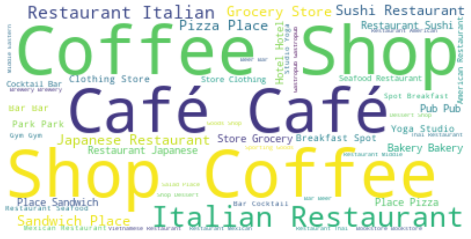

```python
cluster_word_cloud(Cluster1)
```

### Cafe cluster

##### Most common words are Coffee shops. This Cluster good for you if you want to find a good place to drink coffee and eat.

```python
Cluster2 = toronto_merged.loc[toronto_merged['Cluster Labels'] == 1, toronto_merged.columns[[1] + list(range(5, toronto_merged.shape[1]))]]
Cluster2.head()
```

|  | Borough | Cluster Labels | 1st Most Common Venue | 2nd Most Common Venue | 3rd Most Common Venue | 4th Most Common Venue | 5th Most Common Venue | 6th Most Common Venue | 7th Most Common Venue | 8th Most Common Venue | 9th Most Common Venue | 10th Most Common Venue |
| --- | --- | --- | --- | --- | --- | --- | --- | --- | --- | --- | --- | --- |
| 4 | East Toronto | 1 | Trail | Pub | Health Food Store | Yoga Studio | Dim Sum Restaurant | Diner | Discount Store | Distribution Center | Dog Run | Doner Restaurant |
| 15 | East Toronto | 1 | Sandwich Place | Fast Food Restaurant | Pub | Food & Drink Shop | Burrito Place | Liquor Store | Italian Restaurant | Restaurant | Intersection | Ice Cream Shop |
| 19 | Central Toronto | 1 | Ice Cream Shop | Home Service | Garden | Yoga Studio | Event Space | Ethiopian Restaurant | Electronics Store | Eastern European Restaurant | Dumpling Restaurant | Donut Shop |
| 21 | Central Toronto | 1 | Jewelry Store | Trail | Sushi Restaurant | Mexican Restaurant | Yoga Studio | Dim Sum Restaurant | Ethiopian Restaurant | Electronics Store | Eastern European Restaurant | Dumpling Restaurant |
| 32 | Downtown Toronto | 1 | Airport Service | Airport Lounge | Airport Terminal | Sculpture Garden | Rental Car Location | Boat or Ferry | Plane | Boutique | Harbor / Marina | Coffee Shop |

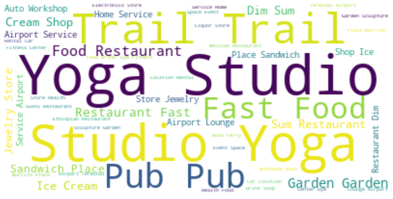

```python
cluster_word_cloud(Cluster2)
```

### Relaxing cluster

```python
Cluster3 = toronto_merged.loc[toronto_merged['Cluster Labels'] == 2, toronto_merged.columns[[1] + list(range(5, toronto_merged.shape[1]))]]
Cluster3.head()
```

|  | Borough | Cluster Labels | 1st Most Common Venue | 2nd Most Common Venue | 3rd Most Common Venue | 4th Most Common Venue | 5th Most Common Venue | 6th Most Common Venue | 7th Most Common Venue | 8th Most Common Venue | 9th Most Common Venue | 10th Most Common Venue |
| --- | --- | --- | --- | --- | --- | --- | --- | --- | --- | --- | --- | --- |
| 29 | Central Toronto | 2 | Park | Gym | Dessert Shop | Event Space | Ethiopian Restaurant | Electronics Store | Eastern European Restaurant | Dumpling Restaurant | Donut Shop | Doner Restaurant |
| 33 | Downtown Toronto | 2 | Park | Playground | Trail | Department Store | Ethiopian Restaurant | Electronics Store | Eastern European Restaurant | Dumpling Restaurant | Donut Shop | Doner Restaurant |

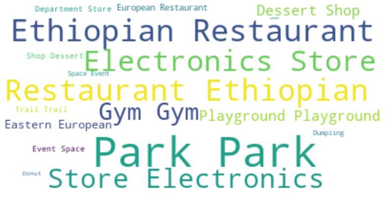

```python
cluster_word_cloud(Cluster3)
```

### Health cluster

##### Most common words are Park, Ethiopian restaurant, gym. This Cluster good for you if you want to take care of your health

```python
Cluster4 = toronto_merged.loc[toronto_merged['Cluster Labels'] == 3, toronto_merged.columns[[1] + list(range(5, toronto_merged.shape[1]))]]
Cluster4
```

|  | Borough | Cluster Labels | 1st Most Common Venue | 2nd Most Common Venue | 3rd Most Common Venue | 4th Most Common Venue | 5th Most Common Venue | 6th Most Common Venue | 7th Most Common Venue | 8th Most Common Venue | 9th Most Common Venue | 10th Most Common Venue |
| --- | --- | --- | --- | --- | --- | --- | --- | --- | --- | --- | --- | --- |
| 18 | Central Toronto | 3 | Park | Bus Line | Swim School | Dim Sum Restaurant | Event Space | Ethiopian Restaurant | Electronics Store | Eastern European Restaurant | Dumpling Restaurant | Donut Shop |

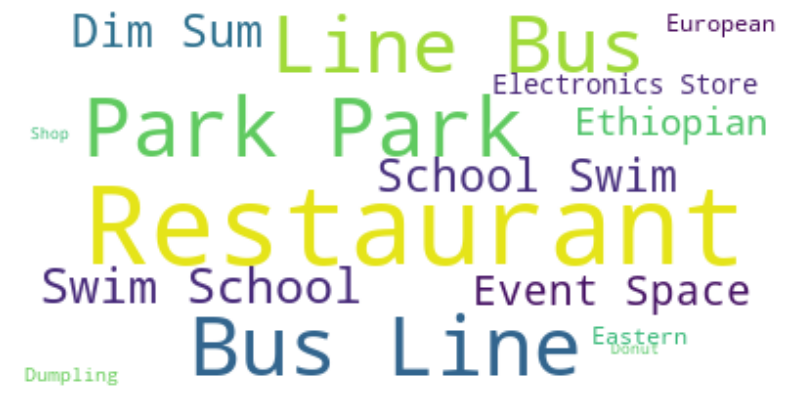

```python
cluster_word_cloud(Cluster4)
```

### Park cluster

##### Most common words are Park, Restaurant. This Cluster good for you if you want to spend some time at a park. Really simillar for cluster #3